# q=8 hierarchical harmonic-worldtube matching

```python
def iterative_training_residual(
        first_order_parameters,
        second_order_parameters,
        raw_values, raw_derivatives,
        radius_indices=ITERATIVE_TRAINING_RADIUS_INDICES):
    residual_parts = []
    data_parts = []
    for radius_index in radius_indices:
        first_order_value = metric_linear_combination(
            ITERATIVE_FIRST_ORDER_COLUMNS[radius_index],
            first_order_parameters,
        )
        first_order_derivative = metric_linear_combination(
            ITERATIVE_FIRST_ORDER_DERIVATIVES[radius_index],
            first_order_parameters,
        )
        quadratic_value, quadratic_derivative = (
            quadratic_value_and_derivative(
                first_order_parameters, radius_index))
        second_order_value, second_order_derivative = (
            second_order_value_and_derivative(
                second_order_parameters, radius_index))
        residual_parts.extend((
            metric_values_by_point(subtract_metric(
                raw_values[radius_index],
                first_order_value,
                quadratic_value,
                second_order_value,
            )).ravel(),
            ITERATIVE_SECOND_ORDER_DERIVATIVE_WEIGHT
            * metric_values_by_point(subtract_metric(
                raw_derivatives[radius_index],
                first_order_derivative,
                quadratic_derivative,
                second_order_derivative,
            )).ravel(),
        ))
        data_parts.extend((
            metric_values_by_point(
                raw_values[radius_index]).ravel(),
            ITERATIVE_SECOND_ORDER_DERIVATIVE_WEIGHT
            * metric_values_by_point(
                raw_derivatives[radius_index]).ravel(),
        ))
    return (
        np.linalg.norm(np.concatenate(residual_parts))
        / np.linalg.norm(np.concatenate(data_parts))
    )


def iterative_interior_error(
        first_order_parameters, second_order_parameters):
    first_order_values = np.einsum(
        "ncp,p->nc",
        INTERIOR_RESPONSE_DESIGN,
        first_order_parameters,
    )
    quadratic_values = metric_values_by_point(
        known_quadratic_first_order_source(
            INTERIOR_LOCAL_POINTS,
            first_order_parameters[1:4],
            symmetric_matrix_from_six(
                first_order_parameters[7:13]),
            SMALL_BLACK_HOLE_MASS,
        )
    )
    second_order_values = np.einsum(
        "ncp,p->nc",
        INTERIOR_FULL_SECOND_ORDER_DESIGN,
        second_order_parameters,
    )
    model = (
        INTERIOR_BACKGROUND_VALUES
        + first_order_values
        + quadratic_values
        + second_order_values
    )
    return (
        np.linalg.norm(INTERIOR_NUMERICAL_VALUES - model)
        / np.linalg.norm(INTERIOR_NUMERICAL_VALUES)
    )


def run_alternating_iteration(
        raw_values, raw_derivatives, damping,
        number_of_iterations=ITERATIVE_MAX_ITERATIONS,
        interior_error_function=None,
        true_first_order=None, true_second_order=None,
        radius_indices=ITERATIVE_TRAINING_RADIUS_INDICES):
    zero_value_corrections = [
        zero_metric_like(metric) for metric in raw_values]
    zero_derivative_corrections = [
        zero_metric_like(metric) for metric in raw_derivatives]
    first_order = fit_iterative_first_order(
        raw_values,
        raw_derivatives,
        zero_value_corrections,
        zero_derivative_corrections,
        radius_indices,
    )
    second_order = np.zeros(
        number_of_full_second_order_parameters)

    history = {
        "first_order": [first_order.copy()],
        "second_order": [second_order.copy()],
        "training_residual": [
            iterative_training_residual(
                first_order, second_order,
                raw_values, raw_derivatives,
                radius_indices)],
        "first_order_update": [np.nan],
        "second_order_update": [np.nan],
        "interior_error": [
            np.nan if interior_error_function is None
            else interior_error_function(
                first_order, second_order)],
        "first_order_error": [
            np.nan if true_first_order is None
            else np.linalg.norm(
                first_order - true_first_order)
            / max(np.linalg.norm(true_first_order), 1.0e-300)],
        "second_order_error": [
            np.nan if true_second_order is None
            else np.linalg.norm(
                second_order - true_second_order)
            / max(np.linalg.norm(true_second_order), 1.0e-300)],
    }

    for _ in range(number_of_iterations):
        second_order_target = fit_iterative_second_order(
            first_order, raw_values, raw_derivatives,
            radius_indices)
        next_second_order = (
            (1.0 - damping) * second_order
            + damping * second_order_target
        )

        correction_values = []
        correction_derivatives = []
        for radius_index in range(number_of_radii):
            quadratic_value, quadratic_derivative = (
                quadratic_value_and_derivative(
                    first_order, radius_index))
            second_order_value, second_order_derivative = (
                second_order_value_and_derivative(
                    next_second_order, radius_index))
            correction_values.append(add_metrics(
                quadratic_value, second_order_value))
            correction_derivatives.append(add_metrics(
                quadratic_derivative, second_order_derivative))

        first_order_target = fit_iterative_first_order(
            raw_values,
            raw_derivatives,
            correction_values,
            correction_derivatives,
            radius_indices,
        )
        next_first_order = (
            (1.0 - damping) * first_order
            + damping * first_order_target
        )

        history["first_order_update"].append(
            np.linalg.norm(next_first_order - first_order)
            / max(np.linalg.norm(next_first_order), 1.0e-300))
        history["second_order_update"].append(
            np.linalg.norm(next_second_order - second_order)
            / max(np.linalg.norm(next_second_order), 1.0e-300))
        first_order = next_first_order
        second_order = next_second_order
        history["first_order"].append(first_order.copy())
        history["second_order"].append(second_order.copy())
        history["training_residual"].append(
            iterative_training_residual(
                first_order, second_order,
                raw_values, raw_derivatives,
                radius_indices))
        history["interior_error"].append(
            np.nan if interior_error_function is None
            else interior_error_function(
                first_order, second_order))
        history["first_order_error"].append(
            np.nan if true_first_order is None
            else np.linalg.norm(
                first_order - true_first_order)
            / max(np.linalg.norm(true_first_order), 1.0e-300))
        history["second_order_error"].append(
            np.nan if true_second_order is None
            else np.linalg.norm(
                second_order - true_second_order)
            / max(np.linalg.norm(true_second_order), 1.0e-300))
```

```python
    return {
        name: np.asarray(values)
        for name, values in history.items()
    }
```

### Manufactured fixed-point test

Before applying the iteration to simulation data, we manufacture data from exactly the same nonlinear truncated model. The chosen coefficients have realistic magnitudes taken from the current q=8 fits, but the test is otherwise noise-free. Successful recovery verifies more than the individual linear solvers: it checks the signs, ordering, quadratic subtraction, radial derivatives, and alternating update as one coupled calculation.

```python
MANUFACTURED_ITERATIVE_FIRST_ORDER = np.mean(
    SECOND_ORDER_FIRST_ORDER_BASELINES[
        1, ITERATIVE_TRAINING_RADIUS_INDICES],
    axis=0,
)
weight_one_index = int(np.flatnonzero(np.isclose(
    SECOND_ORDER_DERIVATIVE_WEIGHTS, 1.0))[0])
MANUFACTURED_ITERATIVE_SECOND_ORDER = np.mean(
    SECOND_ORDER_JOINT_SUBSET_PARAMETERS[
        1,
        weight_one_index,
        ITERATIVE_TRAINING_RADIUS_INDICES,
    ],
    axis=0,
)

MANUFACTURED_ITERATIVE_RAW_VALUES = []
MANUFACTURED_ITERATIVE_RAW_DERIVATIVES = []
for radius_index in range(number_of_radii):
    first_order_value = metric_linear_combination(
        ITERATIVE_FIRST_ORDER_COLUMNS[radius_index],
        MANUFACTURED_ITERATIVE_FIRST_ORDER,
    )
    first_order_derivative = metric_linear_combination(
        ITERATIVE_FIRST_ORDER_DERIVATIVES[radius_index],
        MANUFACTURED_ITERATIVE_FIRST_ORDER,
    )
    quadratic_value, quadratic_derivative = (
        quadratic_value_and_derivative(
            MANUFACTURED_ITERATIVE_FIRST_ORDER,
            radius_index,
        )
    )
    second_order_value, second_order_derivative = (
        second_order_value_and_derivative(
            MANUFACTURED_ITERATIVE_SECOND_ORDER,
            radius_index,
        )
    )
    MANUFACTURED_ITERATIVE_RAW_VALUES.append(add_metrics(
        first_order_value,
        quadratic_value,
        second_order_value,
    ))
    MANUFACTURED_ITERATIVE_RAW_DERIVATIVES.append(add_metrics(
        first_order_derivative,
        quadratic_derivative,
        second_order_derivative,
    ))

# Verify the exact fixed-point identity separately from the convergence rate
# of an iteration started far from that fixed point.
MANUFACTURED_FIXED_SECOND_ORDER = fit_iterative_second_order(
    MANUFACTURED_ITERATIVE_FIRST_ORDER,
    MANUFACTURED_ITERATIVE_RAW_VALUES,
    MANUFACTURED_ITERATIVE_RAW_DERIVATIVES,
)
manufactured_fixed_correction_values = []
manufactured_fixed_correction_derivatives = []
for radius_index in range(number_of_radii):
    quadratic_value, quadratic_derivative = (
        quadratic_value_and_derivative(
            MANUFACTURED_ITERATIVE_FIRST_ORDER,
            radius_index,
        )
    )
    second_order_value, second_order_derivative = (
        second_order_value_and_derivative(
            MANUFACTURED_FIXED_SECOND_ORDER,
            radius_index,
        )
    )
    manufactured_fixed_correction_values.append(add_metrics(
        quadratic_value, second_order_value))
    manufactured_fixed_correction_derivatives.append(add_metrics(
        quadratic_derivative, second_order_derivative))
MANUFACTURED_FIXED_FIRST_ORDER = fit_iterative_first_order(
    MANUFACTURED_ITERATIVE_RAW_VALUES,
    MANUFACTURED_ITERATIVE_RAW_DERIVATIVES,
    manufactured_fixed_correction_values,
    manufactured_fixed_correction_derivatives,
)
MANUFACTURED_FIXED_FIRST_ORDER_ERROR = (
    np.linalg.norm(
        MANUFACTURED_FIXED_FIRST_ORDER
        - MANUFACTURED_ITERATIVE_FIRST_ORDER)
    / np.linalg.norm(MANUFACTURED_ITERATIVE_FIRST_ORDER)
)
MANUFACTURED_FIXED_SECOND_ORDER_ERROR = (
    np.linalg.norm(
        MANUFACTURED_FIXED_SECOND_ORDER
        - MANUFACTURED_ITERATIVE_SECOND_ORDER)
    / np.linalg.norm(MANUFACTURED_ITERATIVE_SECOND_ORDER)
)
print(
    "manufactured fixed-point identity:",
    f"p1 error={MANUFACTURED_FIXED_FIRST_ORDER_ERROR:.3e},",
    f"p2 error={MANUFACTURED_FIXED_SECOND_ORDER_ERROR:.3e}",
)
assert MANUFACTURED_FIXED_FIRST_ORDER_ERROR < 2.0e-11
assert MANUFACTURED_FIXED_SECOND_ORDER_ERROR < 2.0e-11

MANUFACTURED_ITERATION_RESULTS = [
    run_alternating_iteration(
        MANUFACTURED_ITERATIVE_RAW_VALUES,
        MANUFACTURED_ITERATIVE_RAW_DERIVATIVES,
        damping,
        true_first_order=MANUFACTURED_ITERATIVE_FIRST_ORDER,
        true_second_order=MANUFACTURED_ITERATIVE_SECOND_ORDER,
    )
    for damping in ITERATIVE_DAMPING_VALUES
]

for damping, results in zip(
        ITERATIVE_DAMPING_VALUES,
        MANUFACTURED_ITERATION_RESULTS):
    print(
        f"manufactured lambda={damping:g}: "
        f"p1 error={results['first_order_error'][-1]:.3e}, "
        f"p2 error={results['second_order_error'][-1]:.3e}, "
        f"residual={results['training_residual'][-1]:.3e}"
    )

manufactured_best_index = int(np.argmin([
    results["training_residual"][-1]
    for results in MANUFACTURED_ITERATION_RESULTS
]))
assert (
    MANUFACTURED_ITERATION_RESULTS[
        manufactured_best_index]["training_residual"][-1]
    < MANUFACTURED_ITERATION_RESULTS[
        manufactured_best_index]["training_residual"][0]
)
```

```
manufactured fixed-point identity: p1 error=3.550e-14, p2 error=9.935e-16
```

```
manufactured lambda=0.25: p1 error=4.496e-02, p2 error=6.821e-01, residual=2.128e-02
manufactured lambda=0.5: p1 error=3.356e-02, p2 error=5.115e-01, residual=1.588e-02
manufactured lambda=1: p1 error=1.220e-02, p2 error=1.878e-01, residual=5.777e-03
```

### Alternation on the q=8 slice

We now run precisely the same iteration on the numerical data. Convergence of the iteration is distinct from accuracy of the truncated model. A stable fixed point shows that the two selected blocks can be made mutually consistent; only the held-out interior metric and held-out radii tell us whether that fixed point predicts the simulation.

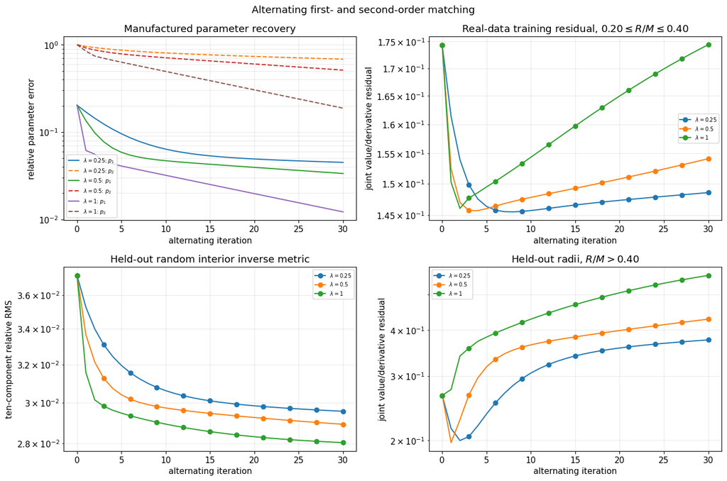

```
Alternating real-data summary
lambda=0.25: final training=1.485656e-01, final held-out radii=3.760284e-01, best interior=2.957038e-02 at iteration 30, final interior=2.957038e-02
lambda=0.5: final training=1.541167e-01, final held-out radii=4.283604e-01, best interior=2.892706e-02 at iteration 30, final interior=2.892706e-02
lambda=1: final training=1.744030e-01, final held-out radii=5.638783e-01, best interior=2.804293e-02 at iteration 30, final interior=2.804293e-02
```

```python
REAL_ITERATION_RESULTS = [
    run_alternating_iteration(
        ITERATIVE_RAW_VALUES,
        ITERATIVE_RAW_DERIVATIVES,
        damping,
        interior_error_function=iterative_interior_error,
    )
    for damping in ITERATIVE_DAMPING_VALUES
]

REAL_ITERATION_HELD_OUT_RESIDUAL = np.empty((
    len(ITERATIVE_DAMPING_VALUES),
    ITERATIVE_MAX_ITERATIONS + 1,
))
for damping_index, results in enumerate(
        REAL_ITERATION_RESULTS):
    for iteration in range(ITERATIVE_MAX_ITERATIONS + 1):
        REAL_ITERATION_HELD_OUT_RESIDUAL[
            damping_index, iteration] = (
                iterative_training_residual(
                    results["first_order"][iteration],
                    results["second_order"][iteration],
                    ITERATIVE_RAW_VALUES,
                    ITERATIVE_RAW_DERIVATIVES,
                    ITERATIVE_HELD_OUT_RADIUS_INDICES,
                )
            )

fig_iterative, axes = plt.subplots(
    2, 2, figsize=(13.5, 9.0))
iteration_numbers = np.arange(
    ITERATIVE_MAX_ITERATIONS + 1)
for damping, manufactured, real, held_out in zip(
        ITERATIVE_DAMPING_VALUES,
        MANUFACTURED_ITERATION_RESULTS,
        REAL_ITERATION_RESULTS,
        REAL_ITERATION_HELD_OUT_RESIDUAL,
):
    label = rf"$\lambda={damping:g}$"
    axes[0, 0].semilogy(
        iteration_numbers,
        manufactured["first_order_error"],
        "-",
        label=label + r": $p_1$",
    )
    axes[0, 0].semilogy(
        iteration_numbers,
        manufactured["second_order_error"],
        "--",
        label=label + r": $p_2$",
    )
    axes[0, 1].semilogy(
        iteration_numbers,
        real["training_residual"],
        "o-",
        markevery=3,
        label=label,
    )
    axes[1, 0].semilogy(
        iteration_numbers,
        real["interior_error"],
        "o-",
        markevery=3,
        label=label,
    )
    axes[1, 1].semilogy(
        iteration_numbers,
        held_out,
        "o-",
        markevery=3,
        label=label,
    )

axes[0, 0].set_title("Manufactured parameter recovery")
axes[0, 0].set_ylabel("relative parameter error")
axes[0, 1].set_title(
    r"Real-data training residual, $0.20\leq R/M\leq0.40$")
axes[0, 1].set_ylabel("joint value/derivative residual")
axes[1, 0].set_title("Held-out random interior inverse metric")
axes[1, 0].set_ylabel("ten-component relative RMS")
axes[1, 1].set_title(
    r"Held-out radii, $R/M>0.40$")
axes[1, 1].set_ylabel("joint value/derivative residual")
for axis in axes.flat:
    axis.set_xlabel("alternating iteration")
    axis.grid(True, which="both", alpha=0.25)
    axis.legend(fontsize=7)
fig_iterative.suptitle(
    "Alternating first- and second-order matching")
fig_iterative.tight_layout()
fig_iterative.savefig(
    OUTPUT_DIRECTORY
    / "q8_t950_alternating_first_second_order.pdf")
fig_iterative.savefig(
    OUTPUT_DIRECTORY
    / "q8_t950_alternating_first_second_order.png",
    dpi=180,
)
plt.show()


print("\nAlternating real-data summary")
for damping, results, held_out in zip(
        ITERATIVE_DAMPING_VALUES,
        REAL_ITERATION_RESULTS,
        REAL_ITERATION_HELD_OUT_RESIDUAL):
    best_interior_iteration = int(np.argmin(
        results["interior_error"]))
    print(
        f"lambda={damping:g}: "
        f"final training={results['training_residual'][-1]:.6e}, "
        f"final held-out radii={held_out[-1]:.6e}, "
        f"best interior={results['interior_error'][best_interior_iteration]:.6e} "
        f"at iteration {best_interior_iteration}, "
        f"final interior={results['interior_error'][-1]:.6e}"
    )
```

### Interpretation of the iteration

The manufactured test determines whether the alternating map is a valid solver for the truncated equations. The real-data curves answer a different question: whether iterating toward that fixed point improves predictions that were not used in either block solve.

If the training residual converges while the interior or large-radius residual worsens, the iteration is successfully reallocating truncation error between orders but is overfitting the selected blocks. Conversely, a stable minimum shared by several damping factors is evidence that the first- and second-order estimates are mutually consistent. This separation is why the iteration number is treated as a validation axis rather than automatically running to convergence.

The manufactured fixed-point identity is satisfied to (4\times10^{-14}) in (p_1) and (10^{-15}) in (p_2), so the two block solvers and both subtractions are algebraically consistent. Starting from the naive first-order estimate is nevertheless slow: even the undamped iteration retains (1.2%) relative error in (p_1) and (19%) in (p_2) after thirty sweeps. The first- and second-order response spaces are therefore strongly coupled rather than approximately block diagonal.

For the numerical slice, all three damping choices initially lower the training residual. Their minima occur after approximately the same amount of effective iteration: iteration (8) for (\lambda=1/4), (4) for (\lambda=1/2), and (2) for (\lambda=1), at a residual near (0.146). Thereafter the residual rises. The held-out-radii residual is even more restrictive: it is minimized at iteration (2), (1), and (0), respectively, and subsequently grows substantially.

The random interior metric behaves differently. Its error decreases monotonically from (3.72\times10^{-2}) to (2.96,2.89,2.80\times10^{-2}) for (\lambda=1/4,1/2,1) after thirty iterations. The smallest value is better than the approximately (3.01\times10^{-2}) globally balanced value-only second-order fit found above, but it coincides with worse extrapolation to larger worldtubes and neither parameter block has converged.

So the experiment supports the *possibility* of iterative decontamination, but not unrestricted iteration to a fixed point. At present it is best viewed as a regularization path: an iteration count of order one to four gives a reproducible compromise between the small-radius equations and nearby held-out radii, while later sweeps continue improving this particular interior point set by reallocating unresolved higher-order content into (p_1) and (p_2). Additional time slices or derivative observables are needed to decide which validation target is physically predictive.

## 16. Radius-by-radius alternating matching

We now perform the matching independently on each worldtube. For a fixed radius (R), [ \begin{aligned} d(R) &= A_1(R)p_1(R) +Q_{11}[p_1(R),p_1(R)]+A_2(R)p_2(R),\\ d_D(R) &= A_{1D}(R)p_1(R) +Q_{11,D}[p_1(R),p_1(R)]+A_{2D}(R)p_2(R). \end{aligned} ] No information from any other radius enters either least-squares solve. The system is nevertheless overdetermined because the ten metric components at all angular points and their radial derivatives provide many more equations than the thirteen first-order and seven selected second-order coefficients.

At every radius from (0.20M) through (0.80M) we initialize (p_1^{(0)}(R)) with the same derivative-assisted (V1+C3) estimator, alternate the two undamped block solves for thirty iterations, and retain the complete trajectory. The value-plus-derivative residual on that sphere is training information. The metric at the common random points inside the (R=0.20M) sphere is not used by either solve and is the primary held-out diagnostic.

```python
RADIUS_BY_RADIUS_DAMPING = 1.0
RADIUS_BY_RADIUS_MAX_RADIUS = 0.8
RADIUS_BY_RADIUS_RADIUS_INDICES = np.flatnonzero(
    RADIUS_TEST_VALUES <= RADIUS_BY_RADIUS_MAX_RADIUS)
RADIUS_BY_RADIUS_RADII = RADIUS_TEST_VALUES[
    RADIUS_BY_RADIUS_RADIUS_INDICES]
RADIUS_BY_RADIUS_RADIUS_OVER_SMALL_MASS = (
    RADIUS_OVER_SMALL_MASS[
        RADIUS_BY_RADIUS_RADIUS_INDICES])
RADIUS_BY_RADIUS_ITERATION_RESULTS = [
    run_alternating_iteration(
        ITERATIVE_RAW_VALUES,
        ITERATIVE_RAW_DERIVATIVES,
        RADIUS_BY_RADIUS_DAMPING,
        interior_error_function=iterative_interior_error,
        radius_indices=np.asarray([radius_index]),
    )
    for radius_index in RADIUS_BY_RADIUS_RADIUS_INDICES
]

RADIUS_BY_RADIUS_FIRST_ORDER = np.asarray([
    result["first_order"]
    for result in RADIUS_BY_RADIUS_ITERATION_RESULTS
])
RADIUS_BY_RADIUS_SECOND_ORDER = np.asarray([
    result["second_order"]
    for result in RADIUS_BY_RADIUS_ITERATION_RESULTS
])
RADIUS_BY_RADIUS_SURFACE_RESIDUAL = np.asarray([
    result["training_residual"]
    for result in RADIUS_BY_RADIUS_ITERATION_RESULTS
])
RADIUS_BY_RADIUS_INTERIOR_ERROR = np.asarray([
    result["interior_error"]
    for result in RADIUS_BY_RADIUS_ITERATION_RESULTS
])
RADIUS_BY_RADIUS_FIRST_ORDER_UPDATE = np.asarray([
    result["first_order_update"]
    for result in RADIUS_BY_RADIUS_ITERATION_RESULTS
])
RADIUS_BY_RADIUS_SECOND_ORDER_UPDATE = np.asarray([
    result["second_order_update"]
    for result in RADIUS_BY_RADIUS_ITERATION_RESULTS
])

# The known manufactured solution must be an exact fixed point at every
# individual radius, independently of how fast an iteration approaches it.
RADIUS_BY_RADIUS_MANUFACTURED_P1_ERROR = np.empty(
    len(RADIUS_BY_RADIUS_RADIUS_INDICES))
RADIUS_BY_RADIUS_MANUFACTURED_P2_ERROR = np.empty(
    len(RADIUS_BY_RADIUS_RADIUS_INDICES))
for local_radius_index, radius_index in enumerate(
        RADIUS_BY_RADIUS_RADIUS_INDICES):
    radius_indices = np.asarray([radius_index])
    fixed_second_order = fit_iterative_second_order(
        MANUFACTURED_ITERATIVE_FIRST_ORDER,
        MANUFACTURED_ITERATIVE_RAW_VALUES,
        MANUFACTURED_ITERATIVE_RAW_DERIVATIVES,
        radius_indices,
    )
    correction_values = [
        zero_metric_like(metric)
        for metric in MANUFACTURED_ITERATIVE_RAW_VALUES
    ]
    correction_derivatives = [
        zero_metric_like(metric)
        for metric in MANUFACTURED_ITERATIVE_RAW_DERIVATIVES
    ]
    quadratic_value, quadratic_derivative = (
        quadratic_value_and_derivative(
            MANUFACTURED_ITERATIVE_FIRST_ORDER,
            radius_index,
        )
    )
    second_order_value, second_order_derivative = (
        second_order_value_and_derivative(
            fixed_second_order, radius_index)
    )
    correction_values[radius_index] = add_metrics(
        quadratic_value, second_order_value)
    correction_derivatives[radius_index] = add_metrics(
        quadratic_derivative, second_order_derivative)
    fixed_first_order = fit_iterative_first_order(
        MANUFACTURED_ITERATIVE_RAW_VALUES,
        MANUFACTURED_ITERATIVE_RAW_DERIVATIVES,
        correction_values,
        correction_derivatives,
        radius_indices,
    )
    RADIUS_BY_RADIUS_MANUFACTURED_P1_ERROR[
        local_radius_index] = (
        np.linalg.norm(
            fixed_first_order
            - MANUFACTURED_ITERATIVE_FIRST_ORDER)
        / np.linalg.norm(MANUFACTURED_ITERATIVE_FIRST_ORDER)
    )
    RADIUS_BY_RADIUS_MANUFACTURED_P2_ERROR[
        local_radius_index] = (
        np.linalg.norm(
            fixed_second_order
            - MANUFACTURED_ITERATIVE_SECOND_ORDER)
        / np.linalg.norm(MANUFACTURED_ITERATIVE_SECOND_ORDER)
    )

print(
    "maximum single-radius manufactured fixed-point errors:",
    f"p1={RADIUS_BY_RADIUS_MANUFACTURED_P1_ERROR.max():.3e},",
    f"p2={RADIUS_BY_RADIUS_MANUFACTURED_P2_ERROR.max():.3e}",
)
assert RADIUS_BY_RADIUS_MANUFACTURED_P1_ERROR.max() < 2.0e-10
assert RADIUS_BY_RADIUS_MANUFACTURED_P2_ERROR.max() < 2.0e-10
```

```
maximum single-radius manufactured fixed-point errors: p1=9.377e-14, p2=2.633e-15
```

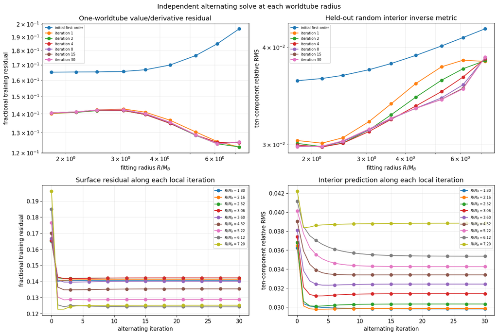

```
Radius-by-radius alternating summary
 R/M_B   best surface (iteration, residual)   best interior (iteration, error)
  1.80   ( 1, 1.401585e-01)   (30, 2.980156e-02)
  2.16   ( 2, 1.407744e-01)   ( 3, 2.976985e-02)
  2.52   ( 2, 1.417733e-01)   ( 3, 3.008025e-02)
  3.06   ( 2, 1.417860e-01)   ( 3, 3.117263e-02)
  3.60   ( 3, 1.395554e-01)   ( 5, 3.230435e-02)
  4.32   ( 2, 1.347569e-01)   (11, 3.339254e-02)
  5.22   ( 2, 1.285508e-01)   (30, 3.426184e-02)
  6.12   (30, 1.241942e-01)   (30, 3.536346e-02)
  7.20   ( 1, 1.226832e-01)   ( 1, 3.835403e-02)
```

```python
RADIUS_BY_RADIUS_PLOT_ITERATIONS = np.array([
    0, 1, 2, 4, 8, 15, ITERATIVE_MAX_ITERATIONS,
])
fig_radius_iteration, axes = plt.subplots(
    2, 2, figsize=(14.0, 9.5))

for iteration in RADIUS_BY_RADIUS_PLOT_ITERATIONS:
    label = (
        "initial first order" if iteration == 0
        else f"iteration {iteration}")
    axes[0, 0].loglog(
        RADIUS_BY_RADIUS_RADIUS_OVER_SMALL_MASS,
        RADIUS_BY_RADIUS_SURFACE_RESIDUAL[:, iteration],
        "o-",
        label=label,
    )
    axes[0, 1].loglog(
        RADIUS_BY_RADIUS_RADIUS_OVER_SMALL_MASS,
        RADIUS_BY_RADIUS_INTERIOR_ERROR[:, iteration],
        "o-",
        label=label,
    )

for local_radius_index, radius in enumerate(
        RADIUS_BY_RADIUS_RADIUS_OVER_SMALL_MASS):
    axes[1, 0].plot(
        np.arange(ITERATIVE_MAX_ITERATIONS + 1),
        RADIUS_BY_RADIUS_SURFACE_RESIDUAL[
            local_radius_index],
        "o-",
        markevery=3,
        label=rf"$R/M_B={radius:.2f}$",
    )
    axes[1, 1].plot(
        np.arange(ITERATIVE_MAX_ITERATIONS + 1),
        RADIUS_BY_RADIUS_INTERIOR_ERROR[
            local_radius_index],
        "o-",
        markevery=3,
        label=rf"$R/M_B={radius:.2f}$",
    )

axes[0, 0].set_title(
    "One-worldtube value/derivative residual")
axes[0, 0].set_ylabel("fractional training residual")
axes[0, 1].set_title(
    "Held-out random interior inverse metric")
axes[0, 1].set_ylabel("ten-component relative RMS")
axes[1, 0].set_title(
    "Surface residual along each local iteration")
axes[1, 0].set_ylabel("fractional training residual")
axes[1, 1].set_title(
    "Interior prediction along each local iteration")
axes[1, 1].set_ylabel("ten-component relative RMS")
for axis in axes.flat:
    axis.grid(True, which="both", alpha=0.25)
    axis.legend(fontsize=7)
axes[0, 0].set_xlabel(r"fitting radius $R/M_B$")
axes[0, 1].set_xlabel(r"fitting radius $R/M_B$")
axes[1, 0].set_xlabel("alternating iteration")
axes[1, 1].set_xlabel("alternating iteration")
fig_radius_iteration.suptitle(
    "Independent alternating solve at each worldtube radius")
fig_radius_iteration.tight_layout()
fig_radius_iteration.savefig(
    OUTPUT_DIRECTORY
    / "q8_t950_radius_by_radius_iteration.pdf")
fig_radius_iteration.savefig(
    OUTPUT_DIRECTORY
    / "q8_t950_radius_by_radius_iteration.png",
    dpi=180,
)
plt.show()


RADIUS_BY_RADIUS_BEST_SURFACE_ITERATION = np.argmin(
    RADIUS_BY_RADIUS_SURFACE_RESIDUAL, axis=1)
RADIUS_BY_RADIUS_BEST_INTERIOR_ITERATION = np.argmin(
    RADIUS_BY_RADIUS_INTERIOR_ERROR, axis=1)
print("\nRadius-by-radius alternating summary")
print(
    " R/M_B   best surface (iteration, residual)"
    "   best interior (iteration, error)"
)
for local_radius_index, radius in enumerate(
        RADIUS_BY_RADIUS_RADIUS_OVER_SMALL_MASS):
    surface_iteration = int(
        RADIUS_BY_RADIUS_BEST_SURFACE_ITERATION[
            local_radius_index])
    interior_iteration = int(
        RADIUS_BY_RADIUS_BEST_INTERIOR_ITERATION[
            local_radius_index])
    print(
        f" {radius:5.2f}"
        f"   ({surface_iteration:2d}, "
        f"{RADIUS_BY_RADIUS_SURFACE_RESIDUAL[
            local_radius_index, surface_iteration]:.6e})"
        f"   ({interior_iteration:2d}, "
        f"{RADIUS_BY_RADIUS_INTERIOR_ERROR[
            local_radius_index, interior_iteration]:.6e})"
    )
```

### Reading the radius-by-radius iteration

The surface curve measures how closely the selected truncated model satisfies the equations on the worldtube that determined it. The interior curve asks whether the same coefficients predict independent metric values closer to the black hole. Agreement between their preferred iteration counts is stronger evidence than improvement of either diagnostic alone.

Parameter convergence is not required for a useful early-stopped model. However, a rapidly growing (|p_2(R)|), strong radius dependence, or continued surface improvement accompanied by worsening interior prediction indicates that the iteration is assigning truncation error to poorly identified coefficients.

The useful behavior is concentrated at the smaller radii. At (R=0.24M), the held-out interior error falls from (3.65\times10^{-2}) to (2.98\times10^{-2}) and reaches its minimum after three iterations. The neighboring (R=0.28M), (0.34M), and (0.40M) fits prefer roughly three to five iterations and give minimum errors (3.01,3.12,3.23\times10^{-2}), respectively. At the smallest (R=0.20M), the improvement is slower but remains monotone through iteration thirty, reaching (2.98\times10^{-2}).

The surface residual usually reaches its minimum earlier—after one to three iterations—than the interior metric. This is direct evidence that iterating to optimize the worldtube equations alone is not the correct stopping rule. The analysis is deliberately capped at (R=0.8M), before the large-radius instability seen in the exploratory scan can compress the plotting scale. Within this range, the radius-by-radius result supports a small number of alternating decontamination steps, with the interior metric used to choose the iteration count. It does not support unrestricted iteration at every radius.

```python
def print_best_closure(
        sector_name, labels, results):
    print(f"\n{sector_name}")
    for estimator_index, label in enumerate(labels):
        values = results["held_out_residuals"][
            estimator_index]
        best_index = int(np.argmin(values))
        print(
            f"{label:<42s} "
            f"best closure={values[best_index]:.6e} "
            f"at R/M_B={RADIUS_OVER_SMALL_MASS[best_index]:.3f}; "
            f"range=[{values.min():.6e}, {values.max():.6e}]"
        )


print_best_closure(
    "Vector-sector closure",
    VECTOR_LABELS,
    VECTOR_RESULTS,
)
print_best_closure(
    "Clock/strain-sector closure",
    CLOCK_STRAIN_LABELS,
    CLOCK_STRAIN_RESULTS,
)

np.savez_compressed(
    OUTPUT_DIRECTORY / "q8_t950_first_order_results.npz",
    test_time=TEST_TIME,
    observation_id=TEST_OBSERVATION_ID,
    mass=SMALL_BLACK_HOLE_MASS,
    ah_center=AH_B_CENTER,
    curvature_center=CURVATURE_CENTER,
    radii=RADIUS_TEST_VALUES,
    radius_over_small_mass=RADIUS_OVER_SMALL_MASS,
    center_corrections_by_radius=CENTER_CORRECTIONS_BY_RADIUS,
    vector_labels=np.asarray(VECTOR_LABELS),
    clock_strain_labels=np.asarray(CLOCK_STRAIN_LABELS),
    vector_estimates=VECTOR_RESULTS["estimates"],
    clock_strain_estimates=CLOCK_STRAIN_RESULTS["estimates"],
    vector_condition_numbers=VECTOR_RESULTS["condition_numbers"],
    clock_strain_condition_numbers=(
        CLOCK_STRAIN_RESULTS["condition_numbers"]),
    vector_fit_residuals=VECTOR_RESULTS["fitted_block_residuals"],
    clock_strain_fit_residuals=(
        CLOCK_STRAIN_RESULTS["fitted_block_residuals"]),
    vector_held_out_residuals=(
        VECTOR_RESULTS["held_out_residuals"]),
    clock_strain_held_out_residuals=(
        CLOCK_STRAIN_RESULTS["held_out_residuals"]),
    vector_held_out_rms=VECTOR_RESULTS["held_out_rms"],
    clock_strain_held_out_rms=(
        CLOCK_STRAIN_RESULTS["held_out_rms"]),
    interior_random_seed=INTERIOR_RANDOM_SEED,
    interior_radial_edges=INTERIOR_RADIAL_EDGES,
    interior_local_points=INTERIOR_LOCAL_POINTS,
    interior_shell_index=INTERIOR_SHELL_INDEX,
    interior_zeroth_order_error=(
        INTERIOR_ZEROTH_ORDER_ERROR),
    interior_first_order_parameters=(
        INTERIOR_FIRST_ORDER_PARAMETERS),
    interior_total_error=INTERIOR_TOTAL_ERROR,
    interior_perturbation_residual=(
        INTERIOR_PERTURBATION_RESIDUAL),
    interior_shell_error=INTERIOR_SHELL_ERROR,
    selected_interior_pair=np.asarray(
        SELECTED_INTERIOR_PAIR),
    global_interior_minimum_index=np.asarray(
        GLOBAL_INTERIOR_MINIMUM_INDEX),
    surface_parameter_response_rms=(
        SURFACE_PARAMETER_RESPONSE_RMS),
    block_smallest_nonzero_singular_value=(
        BLOCK_SMALLEST_NONZERO_SINGULAR_VALUE),
    block_active_parameter_count=(
        BLOCK_ACTIVE_PARAMETER_COUNT),
    vector_smallest_singular_value=(
        VECTOR_SMALLEST_SINGULAR_VALUE),
    clock_smallest_singular_value=(
        CLOCK_SMALLEST_SINGULAR_VALUE),
    vector_interior_amplification=(
        VECTOR_INTERIOR_AMPLIFICATION),
    clock_interior_amplification=(
        CLOCK_INTERIOR_AMPLIFICATION),
    parameter_ensemble_mean=PARAMETER_ENSEMBLE_MEAN,
    parameter_ensemble_spread=(
        PARAMETER_ENSEMBLE_SPREAD),
    interior_parameter_contribution=(
        INTERIOR_PARAMETER_CONTRIBUTION),
    interior_parameter_uncertainty_impact=(
        INTERIOR_PARAMETER_UNCERTAINTY_IMPACT),
    interior_group_prediction_spread=(
        INTERIOR_GROUP_PREDICTION_SPREAD),
    interior_total_prediction_spread=(
        INTERIOR_TOTAL_PREDICTION_SPREAD),
    provisional_parameters=PROVISIONAL_PARAMETERS,
    provisional_vector_closure_fraction=(
        PROVISIONAL_VECTOR_CLOSURE_FRACTION),
    provisional_vector_closure_rms=(
        PROVISIONAL_VECTOR_CLOSURE_RMS),
    provisional_gti2_closure_fraction=(
        PROVISIONAL_GTI2_CLOSURE_FRACTION),
    provisional_gti2_closure_rms=(
        PROVISIONAL_GTI2_CLOSURE_RMS),
    provisional_gij1_closure_fraction=(
        PROVISIONAL_GIJ1_CLOSURE_FRACTION),
    provisional_gij1_closure_rms=(
        PROVISIONAL_GIJ1_CLOSURE_RMS),
    provisional_clock_closure_fraction=(
        PROVISIONAL_CLOCK_CLOSURE_FRACTION),
    provisional_clock_closure_rms=(
        PROVISIONAL_CLOCK_CLOSURE_RMS),
    provisional_gij0_diagnostic_fraction=(
        PROVISIONAL_GIJ0_DIAGNOSTIC_FRACTION),
    provisional_gij0_diagnostic_rms=(
        PROVISIONAL_GIJ0_DIAGNOSTIC_RMS),
    provisional_interior_total_error=(
        PROVISIONAL_INTERIOR_TOTAL_ERROR),
    provisional_interior_perturbation_residual=(
        PROVISIONAL_INTERIOR_PERTURBATION_RESIDUAL),
    provisional_interior_shell_error=(
        PROVISIONAL_INTERIOR_SHELL_ERROR),
    provisional_best_interior_radius_index=(
        PROVISIONAL_BEST_INTERIOR_RADIUS_INDEX),
    provisional_pointwise_relative_error=(
        PROVISIONAL_POINTWISE_RELATIVE_ERROR),
    zeroth_pointwise_relative_error=(
        ZEROTH_POINTWISE_RELATIVE_ERROR),
    phi_finite_difference_relative_error=(
        PHI_FINITE_DIFFERENCE_RELATIVE_ERROR),
    analytic_derivative_stencil_error=(
        ANALYTIC_DERIVATIVE_STENCIL_ERROR),
    derivative_v1_fraction=(
        DERIVATIVE_CLOSURES["V1 fitted blocks"][0]),
    derivative_v1_rms=(
        DERIVATIVE_CLOSURES["V1 fitted blocks"][1]),
    derivative_c3_fraction=(
        DERIVATIVE_CLOSURES["C3 fitted blocks"][0]),
    derivative_c3_rms=(
        DERIVATIVE_CLOSURES["C3 fitted blocks"][1]),
    derivative_vector_closure_fraction=(
        DERIVATIVE_CLOSURES["vector closure"][0]),
    derivative_vector_closure_rms=(
        DERIVATIVE_CLOSURES["vector closure"][1]),
    derivative_clock_closure_fraction=(
        DERIVATIVE_CLOSURES[r"$G^{Ti}_{1}$"][0]),
    derivative_clock_closure_rms=(
        DERIVATIVE_CLOSURES[r"$G^{Ti}_{1}$"][1]),
    derivative_gij0_diagnostic_fraction=(
        DERIVATIVE_CLOSURES[
            r"$G^{ij}_{0}$ diagnostic"][0]),
    derivative_gij0_diagnostic_rms=(
        DERIVATIVE_CLOSURES[
            r"$G^{ij}_{0}$ diagnostic"][1]),
    joint_derivative_weights=JOINT_DERIVATIVE_WEIGHTS,
    joint_parameters=JOINT_PARAMETERS,
    joint_vector_condition_number=(
        JOINT_VECTOR_CONDITION_NUMBER),
    joint_clock_condition_number=(
        JOINT_CLOCK_CONDITION_NUMBER),
    joint_parameter_displacement=(
        JOINT_PARAMETER_DISPLACEMENT),
    joint_value_vector_closure_fraction=(
        JOINT_VALUE_VECTOR_CLOSURE_FRACTION),
    joint_value_vector_closure_rms=(
        JOINT_VALUE_VECTOR_CLOSURE_RMS),
    joint_derivative_vector_closure_fraction=(
        JOINT_DERIVATIVE_VECTOR_CLOSURE_FRACTION),
    joint_derivative_vector_closure_rms=(
        JOINT_DERIVATIVE_VECTOR_CLOSURE_RMS),
    joint_value_clock_closure_fraction=(
        JOINT_VALUE_CLOCK_CLOSURE_FRACTION),
    joint_value_clock_closure_rms=(
        JOINT_VALUE_CLOCK_CLOSURE_RMS),
    joint_derivative_clock_closure_fraction=(
        JOINT_DERIVATIVE_CLOCK_CLOSURE_FRACTION),
    joint_derivative_clock_closure_rms=(
        JOINT_DERIVATIVE_CLOCK_CLOSURE_RMS),
    joint_interior_total_error=(
        JOINT_INTERIOR_TOTAL_ERROR),
    joint_interior_perturbation_residual=(
        JOINT_INTERIOR_PERTURBATION_RESIDUAL),
    hybrid_parameters=HYBRID_PARAMETERS,
    hybrid_interior_total_error=(
        HYBRID_INTERIOR_TOTAL_ERROR),
    hybrid_minimum_interior_error=(
        HYBRID_MINIMUM_INTERIOR_ERROR),
    hybrid_minimum_radius=(
        HYBRID_MINIMUM_RADIUS),
    hybrid_global_index=np.asarray(
        HYBRID_GLOBAL_INDEX),
    second_order_baseline_names=np.asarray(
        SECOND_ORDER_BASELINE_NAMES),
    second_order_first_order_baselines=(
        SECOND_ORDER_FIRST_ORDER_BASELINES),
    second_order_first_order_residual_fraction=(
        SECOND_ORDER_FIRST_ORDER_RESIDUAL_FRACTION),
    second_order_quadratic_residual_fraction=(
        SECOND_ORDER_QUADRATIC_RESIDUAL_FRACTION),
    second_order_quadratic_source_fraction=(
        SECOND_ORDER_QUADRATIC_SOURCE_FRACTION),
    second_order_stage1_parameter_names=np.asarray(
        STAGE1_PARAMETER_NAMES),
    second_order_stage1_parameters=(
        SECOND_ORDER_STAGE1_PARAMETERS),
    second_order_first_order_corrections=(
        SECOND_ORDER_FIRST_ORDER_CORRECTIONS),
    second_order_stage1_gij_residual=(
        SECOND_ORDER_STAGE1_GIJ_RESIDUAL),
    second_order_stage1_condition_number=(
        SECOND_ORDER_STAGE1_CONDITION_NUMBER),
    second_order_stage1_rank=(
        SECOND_ORDER_STAGE1_RANK),
    second_order_first_order_correction_fraction=(
        SECOND_ORDER_FIRST_ORDER_CORRECTION_FRACTION),
    second_order_first_order_interior_error=(
        SECOND_ORDER_FIRST_ORDER_INTERIOR_ERROR),
    second_order_stage1_interior_error=(
        SECOND_ORDER_STAGE1_INTERIOR_ERROR),
    manufactured_stage1_frozen_error=(
        MANUFACTURED_FROZEN_ERROR),
    manufactured_stage1_augmented_error=(
        MANUFACTURED_AUGMENTED_ERROR),
    complete_second_order_parameter_names=np.asarray(
        FULL_PARAMETER_NAMES),
    complete_second_order_parameters=(
        COMPLETE_SECOND_ORDER_PARAMETERS),
    complete_second_order_stage_names=np.asarray(
        COMPLETE_SECOND_ORDER_STAGE_NAMES),
    complete_second_order_stage_candidate_fraction=(
        COMPLETE_SECOND_ORDER_STAGE_CANDIDATE_FRACTION),
    complete_second_order_stage_raw_fraction=(
        COMPLETE_SECOND_ORDER_STAGE_RAW_FRACTION),
    complete_second_order_component_fraction=(
        COMPLETE_SECOND_ORDER_COMPONENT_FRACTION),
    complete_second_order_stage2_gtt_closure=(
        COMPLETE_SECOND_ORDER_STAGE2_GTT_CLOSURE),
    complete_second_order_stage3_gti_closure=(
        COMPLETE_SECOND_ORDER_STAGE3_GTI_CLOSURE),
    complete_second_order_stage2_rank=(
        COMPLETE_SECOND_ORDER_STAGE2_RANK),
    complete_second_order_stage3_rank=(
        COMPLETE_SECOND_ORDER_STAGE3_RANK),
    complete_second_order_stage2_condition=(
        COMPLETE_SECOND_ORDER_STAGE2_CONDITION),
    complete_second_order_stage3_condition=(
        COMPLETE_SECOND_ORDER_STAGE3_CONDITION),
    complete_second_order_quadratic_interior_error=(
        COMPLETE_SECOND_ORDER_QUADRATIC_INTERIOR_ERROR),
    complete_second_order_interior_error=(
        COMPLETE_SECOND_ORDER_INTERIOR_ERROR),
    complete_second_order_interior_perturbation_residual=(
        COMPLETE_SECOND_ORDER_INTERIOR_PERTURBATION_RESIDUAL),
    complete_second_order_pointwise_relative_error=(
        COMPLETE_SECOND_ORDER_POINTWISE_RELATIVE_ERROR),
    manufactured_complete_parameter_error=(
        MANUFACTURED_COMPLETE_PARAMETER_ERROR),
    manufactured_complete_metric_closure=(
        MANUFACTURED_COMPLETE_METRIC_CLOSURE),
    polar_j2_blocks=np.asarray(
        POLAR_J2_BLOCKS),
    polar_j2_estimates=POLAR_J2_ESTIMATES,
    polar_j2_block_residuals=(
        POLAR_J2_BLOCK_RESIDUALS),
    polar_j2_rank=POLAR_J2_RANK,
    polar_j2_condition=POLAR_J2_CONDITION,
    spatial_orthogonal_estimates=(
        SPATIAL_ORTHOGONAL_ESTIMATES),
    spatial_orthogonal_in_sample=(
        SPATIAL_ORTHOGONAL_IN_SAMPLE),
    spatial_orthogonal_closure=(
        SPATIAL_ORTHOGONAL_CLOSURE),
    spatial_orthogonal_rank=(
        SPATIAL_ORTHOGONAL_RANK),
    spatial_orthogonal_condition=(
        SPATIAL_ORTHOGONAL_CONDITION),
    spatial_j3_estimates=SPATIAL_J3_ESTIMATES,
    spatial_j3_closure=SPATIAL_J3_CLOSURE,
    spatial_j3_rank=SPATIAL_J3_RANK,
    spatial_j3_condition=SPATIAL_J3_CONDITION,
    second_order_sensitivity_group_names=np.asarray(
        SECOND_ORDER_SENSITIVITY_GROUP_NAMES),
    group_only_parameters=GROUP_ONLY_PARAMETERS,
    group_only_surface_residual_fraction=(
        GROUP_ONLY_SURFACE_RESIDUAL_FRACTION),
    group_only_surface_reduction=(
        GROUP_ONLY_SURFACE_REDUCTION),
    group_only_interior_error=(
        GROUP_ONLY_INTERIOR_ERROR),
    group_only_interior_error_ratio=(
        GROUP_ONLY_INTERIOR_ERROR_RATIO),
    group_only_interior_contribution=(
        GROUP_ONLY_INTERIOR_CONTRIBUTION),
```

```python
    group_only_rank=GROUP_ONLY_RANK,
    group_only_condition=GROUP_ONLY_CONDITION,
    second_order_subset_names=np.asarray(
        SECOND_ORDER_SUBSET_NAMES),
    second_order_subset_parameters=(
        SECOND_ORDER_SUBSET_PARAMETERS),
    second_order_subset_surface_fraction=(
        SECOND_ORDER_SUBSET_SURFACE_FRACTION),
    second_order_subset_interior_error=(
        SECOND_ORDER_SUBSET_INTERIOR_ERROR),
    second_order_subset_interior_ratio=(
        SECOND_ORDER_SUBSET_INTERIOR_RATIO),
    second_order_subset_rank=(
        SECOND_ORDER_SUBSET_RANK),
    second_order_subset_condition=(
        SECOND_ORDER_SUBSET_CONDITION),
    complete_ablation_contribution=(
        COMPLETE_ABLATION_CONTRIBUTION),
    complete_ablation_error_ratio=(
        COMPLETE_ABLATION_ERROR_RATIO),
    second_order_derivative_weights=(
        SECOND_ORDER_DERIVATIVE_WEIGHTS),
    second_order_derivative_stencil_error=(
        SECOND_ORDER_DERIVATIVE_STENCIL_ERROR),
    second_order_joint_subset_parameter_indices=(
        PROVISIONAL_SECOND_ORDER_PARAMETER_INDICES),
    second_order_joint_subset_parameters=(
        SECOND_ORDER_JOINT_SUBSET_PARAMETERS),
    second_order_joint_subset_value_residual=(
        SECOND_ORDER_JOINT_SUBSET_VALUE_RESIDUAL),
    second_order_joint_subset_derivative_residual=(
        SECOND_ORDER_JOINT_SUBSET_DERIVATIVE_RESIDUAL),
    second_order_joint_subset_interior_error=(
        SECOND_ORDER_JOINT_SUBSET_INTERIOR_ERROR),
    second_order_joint_subset_condition=(
        SECOND_ORDER_JOINT_SUBSET_CONDITION),
    second_order_joint_polar_parameters=(
        SECOND_ORDER_JOINT_POLAR_PARAMETERS),
    second_order_joint_polar_value_residual=(
        SECOND_ORDER_JOINT_POLAR_VALUE_RESIDUAL),
    second_order_joint_polar_derivative_residual=(
        SECOND_ORDER_JOINT_POLAR_DERIVATIVE_RESIDUAL),
    second_order_joint_polar_interior_error=(
        SECOND_ORDER_JOINT_POLAR_INTERIOR_ERROR),
    second_order_joint_polar_condition=(
        SECOND_ORDER_JOINT_POLAR_CONDITION),
    iterative_training_radius_indices=(
        ITERATIVE_TRAINING_RADIUS_INDICES),
    iterative_held_out_radius_indices=(
        ITERATIVE_HELD_OUT_RADIUS_INDICES),
    iterative_damping_values=ITERATIVE_DAMPING_VALUES,
    iterative_first_order_parameters=np.asarray([
        results["first_order"]
        for results in REAL_ITERATION_RESULTS
    ]),
    iterative_second_order_parameters=np.asarray([
        results["second_order"]
        for results in REAL_ITERATION_RESULTS
    ]),
    iterative_training_residual=np.asarray([
        results["training_residual"]
        for results in REAL_ITERATION_RESULTS
    ]),
    iterative_held_out_residual=(
        REAL_ITERATION_HELD_OUT_RESIDUAL),
    iterative_interior_error=np.asarray([
        results["interior_error"]
        for results in REAL_ITERATION_RESULTS
    ]),
    iterative_first_order_update=np.asarray([
        results["first_order_update"]
        for results in REAL_ITERATION_RESULTS
    ]),
    iterative_second_order_update=np.asarray([
        results["second_order_update"]
        for results in REAL_ITERATION_RESULTS
    ]),
    manufactured_iterative_first_order=(
        MANUFACTURED_ITERATIVE_FIRST_ORDER),
    manufactured_iterative_second_order=(
        MANUFACTURED_ITERATIVE_SECOND_ORDER),
    manufactured_iterative_first_order_error=np.asarray([
        results["first_order_error"]
        for results in MANUFACTURED_ITERATION_RESULTS
    ]),
    manufactured_iterative_second_order_error=np.asarray([
        results["second_order_error"]
        for results in MANUFACTURED_ITERATION_RESULTS
    ]),
    manufactured_iterative_training_residual=np.asarray([
        results["training_residual"]
        for results in MANUFACTURED_ITERATION_RESULTS
    ]),
    radius_by_radius_damping=RADIUS_BY_RADIUS_DAMPING,
    radius_by_radius_max_radius=(
        RADIUS_BY_RADIUS_MAX_RADIUS),
    radius_by_radius_radius_indices=(
        RADIUS_BY_RADIUS_RADIUS_INDICES),
    radius_by_radius_radii=RADIUS_BY_RADIUS_RADII,
    radius_by_radius_radius_over_small_mass=(
        RADIUS_BY_RADIUS_RADIUS_OVER_SMALL_MASS),
    radius_by_radius_first_order=(
        RADIUS_BY_RADIUS_FIRST_ORDER),
    radius_by_radius_second_order=(
        RADIUS_BY_RADIUS_SECOND_ORDER),
    radius_by_radius_surface_residual=(
        RADIUS_BY_RADIUS_SURFACE_RESIDUAL),
    radius_by_radius_interior_error=(
        RADIUS_BY_RADIUS_INTERIOR_ERROR),
    radius_by_radius_first_order_update=(
        RADIUS_BY_RADIUS_FIRST_ORDER_UPDATE),
    radius_by_radius_second_order_update=(
        RADIUS_BY_RADIUS_SECOND_ORDER_UPDATE),
    radius_by_radius_best_surface_iteration=(
        RADIUS_BY_RADIUS_BEST_SURFACE_ITERATION),
    radius_by_radius_best_interior_iteration=(
        RADIUS_BY_RADIUS_BEST_INTERIOR_ITERATION),
    radius_by_radius_manufactured_p1_error=(
        RADIUS_BY_RADIUS_MANUFACTURED_P1_ERROR),
    radius_by_radius_manufactured_p2_error=(
        RADIUS_BY_RADIUS_MANUFACTURED_P2_ERROR),
)
print(
    "\nSaved compact results to",
    OUTPUT_DIRECTORY / "q8_t950_first_order_results.npz",
)
```

```
Vector-sector closure
V1: GTT l=1 + GTI l=0                      best closure=1.733107e-01 at R/M_B=1.800; range=[1.733107e-01, 1.029179e+00]
V2: GTT l=1 + GIJ l=1                      best closure=1.718209e-01 at R/M_B=1.800; range=[1.718209e-01, 4.425642e+00]
V3: GTI l=0 + GTI l=2                      best closure=2.335667e-01 at R/M_B=1.800; range=[2.335667e-01, 1.002507e+00]
V4: GTI l=0 + GIJ l=1                      best closure=3.689210e-01 at R/M_B=6.120; range=[3.689210e-01, 9.092983e-01]
V5: GTI l=2 + GIJ l=1                      best closure=6.487521e-02 at R/M_B=4.320; range=[6.487521e-02, 3.469680e+00]

Clock/strain-sector closure
C1: GTT l=0 + GTI l=1                      best closure=8.115203e-01 at R/M_B=7.200; range=[8.115203e-01, 1.507149e+00]
C2: GTT l=0 + GIJ l=0                      best closure=5.668098e-01 at R/M_B=7.200; range=[5.668098e-01, 3.544116e+00]
C3: GTT l=0 + GIJ l=2                      best closure=1.150586e-01 at R/M_B=7.200; range=[1.150586e-01, 7.387497e-01]
C4: GTI l=1 + GIJ l=0                      best closure=4.353696e-01 at R/M_B=8.640; range=[4.353696e-01, 2.624950e+00]
C5: GTI l=1 + GIJ l=2                      best closure=1.622365e-01 at R/M_B=6.120; range=[1.622365e-01, 3.541782e-01]

Saved compact results to /Users/niko/caltech/spectre/.codex_tmp/q8_joint_derivative/q8_t950_first_order_results.npz
```

## 17. Companion time-derivative analysis

The single-slice analysis above treats the second-order time jets as instantaneous algebraic unknowns. Ten downloaded slices from $T=950M_{\rm tot}$ through $995M_{\rm tot}$ provide two stronger dynamical tests, stored under `temporal_ode_consistency/`.

First, the evolved generalized-harmonic fields give

$$ \partial_Tg_{ab} =\beta^i\Phi_{iab}-\alpha\Pi_{ab}, \qquad \partial_TG^{ab} =-G^{ac}G^{bd}\partial_Tg_{cd}. $$

At fixed local coordinates on a moving sphere,

$$ D_TG^{ab} =\partial_TG^{ab} +v_{\rm center}^i\partial_iG^{ab}. $$

Fitting the first-order response to this derivative measures the rates of all thirteen first-order coefficients. At $R=0.20M_{\rm tot}$, the directly measured clock acceleration and strain-rate scales are approximately

$$ \operatorname{RMS}|\ddot q^0|=3.95\times10^{-5}, \qquad \operatorname{RMS}|M_B\dot\Lambda_{ij}|=1.25\times10^{-5}. $$

The corresponding freely fitted seven-parameter second-order values are $4.08\times10^{-2}$ and $7.16\times10^{-3}$. They are therefore effective residual-reduction directions, not physical measurements of the time derivatives. The direct derivative also shows that the omitted vector rates $\dot b_i$ and $\ddot q^i$ are larger than the clock/strain rates and must be included in any dynamical second-order subsystem.

Second, the fixed-inertial derivative retains the translation response,

$$ \partial_TG^{ab} =-\partial_iG_{(0)}^{ab}\frac{dq^i}{dT} +\sum_A\mathcal R_A^{ab}\frac{dp_A}{dT}. $$

A joint full-rank fit therefore gives a metric-only measurement of the spatial center velocity. This is distinct from the comoving derivative, which cancels translation and measures $\ddot q^i$. There is no analogous absolute $q^0$ translation measurement because the Schwarzschild background is stationary.

## Current status

The following statements are supported by the calculations in this notebook and its time-derivative companion:

- The corrected first-order response and implemented second-order response ordering pass manufactured tests to roundoff.
- V1 is the most reliable current vector estimator; radial derivatives modestly improve it.
- C3 is the most conservative current clock/strain estimator, but its radial derivative is presently more useful as closure than as a fitted equation.
- The complete triangular 43-parameter second-order solve is algebraically correct but fails cross-component and interior validation on this slice.
- The seven-parameter strain-rate/time-acceleration subsystem and the polar-$J=2$ subsystem contain the clearest second-order metric information.
- Direct time derivatives show that freely fitted time jets must be replaced or constrained by their dynamical measurements.
- A few radius-by-radius Gauss--Seidel sweeps can reduce interior error, but unrestricted iteration is not supported; the surface and interior diagnostics prefer different stopping times.

No block is promoted to a production matching prescription solely because it has a small training residual. A final subsystem must remain stable across radii and times and must predict omitted STF blocks, spatial derivatives, and interior metric values.